# Анализ жд грузоперевозок.

План работ:

- Предобработка данных.
- Графическое отображение.
- Создание таблицы с ошибками.

# Предобработка данных.

## Откроем второй лист документа EXCEL:

```python
import pandas as pd
import matplotlib.pyplot as plt
import seaborn as sns
import numpy as np
#from pymystem3 import Mystem
```

```python
data = pd.read_excel('datasets/Задача для аналитика.xlsx', sheet_name='Данные по перевозкам')
```

Ознакомимся с данными:

```python
data.info()
```

```
<class 'pandas.core.frame.DataFrame'>
RangeIndex: 9680 entries, 0 to 9679
Data columns (total 8 columns):
 #   Column              Non-Null Count  Dtype
---  ------              --------------  -----
 0   Название компаний   9680 non-null   object
 1   Год                 9680 non-null   object
 2   Месяц               9680 non-null   object
 3   Страна отправления  9680 non-null   object
 4   Тип вагона          9680 non-null   object
 5   Страна прибытия     9680 non-null   object
 6   Вагонов             9610 non-null   object
 7   Выручка             9665 non-null   object
dtypes: object(8)
memory usage: 605.1+ KB
```

Видны пропуски и некорректные типы данных.

```python
display(data.head(5))
display(data.tail(5))
```

|  | Название компаний | Год | Месяц | Страна отправления | Тип вагона | Страна прибытия | Вагонов | Выручка |
| --- | --- | --- | --- | --- | --- | --- | --- | --- |
| 0 | Компания 1 | 2019 | 1 | АЗЕРБАЙДЖАН | Крытые | БЕЛАРУСЬ | 8200 | 123000 |
| 1 | Компания 1 | 2019 | 1 | АЗЕРБАЙДЖАН | Крытые | РОССИЯ | 200 | 3000 |
| 2 | Компания 1 | 2019 | 1 | АЗЕРБАЙДЖАН | Полувагоны | РОССИЯ | 400 | 6000 |
| 3 | Компания 1 | 2019 | 1 | БЕЛАРУСЬ | Крытые | РОССИЯ | 3800 | 57000 |
| 4 | Компания 1 | 2019 | 1 | БЕЛАРУСЬ | Полувагоны | РОССИЯ | 300 | 4500 |

|  | Название компаний | Год | Месяц | Страна отправления | Тип вагона | Страна прибытия | Вагонов | Выручка |
| --- | --- | --- | --- | --- | --- | --- | --- | --- |
| 9675 | Компания 16 | 2020 | 3 | ТУРЦИЯ | Полувагоны | РОССИЯ | 87 | 1305 |
| 9676 | Компания 16 | 2020 | 3 | УЗБЕКИСТАН | Полувагоны | КАЗАХСТАН | 174 | 2610 |
| 9677 | Компания 16 | 2020 | 3 | УЗБЕКИСТАН | Полувагоны | РОССИЯ | 783 | 11745 |
| 9678 | Компания 16 | 2020 | 3 | Украина | Полувагоны | КАЗАХСТАН | 1479 | 22185 |
| 9679 | Компания 16 | 2020 | 3 | ШРИ-ЛАНКА | Полувагоны | КАЗАХСТАН | 87 | 1305 |

### Переименуем названия столбцов в более читабельные:

```python
list_data_columns = data.columns.tolist()
for i in range(0, 8):
    list_data_columns[i] = list_data_columns[i].replace(' ', '_').lower()
list_data_columns[6] = 'количество_вагонов'
print(list_data_columns)
data.columns = list_data_columns
```

```
['название_компаний', 'год', 'месяц', 'страна_отправления', 'тип_вагона', 'страна_прибытия', 'количество_вагонов', 'выручка']
```

```python
display(data.head(5))
display(data.tail(5))
```

|  | название_компаний | год | месяц | страна_отправления | тип_вагона | страна_прибытия | количество_вагонов | выручка |
| --- | --- | --- | --- | --- | --- | --- | --- | --- |
| 0 | Компания 1 | 2019 | 1 | АЗЕРБАЙДЖАН | Крытые | БЕЛАРУСЬ | 8200 | 123000 |
| 1 | Компания 1 | 2019 | 1 | АЗЕРБАЙДЖАН | Крытые | РОССИЯ | 200 | 3000 |
| 2 | Компания 1 | 2019 | 1 | АЗЕРБАЙДЖАН | Полувагоны | РОССИЯ | 400 | 6000 |
| 3 | Компания 1 | 2019 | 1 | БЕЛАРУСЬ | Крытые | РОССИЯ | 3800 | 57000 |
| 4 | Компания 1 | 2019 | 1 | БЕЛАРУСЬ | Полувагоны | РОССИЯ | 300 | 4500 |

|  | название_компаний | год | месяц | страна_отправления | тип_вагона | страна_прибытия | количество_вагонов | выручка |
| --- | --- | --- | --- | --- | --- | --- | --- | --- |
| 9675 | Компания 16 | 2020 | 3 | ТУРЦИЯ | Полувагоны | РОССИЯ | 87 | 1305 |
| 9676 | Компания 16 | 2020 | 3 | УЗБЕКИСТАН | Полувагоны | КАЗАХСТАН | 174 | 2610 |
| 9677 | Компания 16 | 2020 | 3 | УЗБЕКИСТАН | Полувагоны | РОССИЯ | 783 | 11745 |
| 9678 | Компания 16 | 2020 | 3 | Украина | Полувагоны | КАЗАХСТАН | 1479 | 22185 |
| 9679 | Компания 16 | 2020 | 3 | ШРИ-ЛАНКА | Полувагоны | КАЗАХСТАН | 87 | 1305 |

### Посмотрим на уникальные типы данных в таблице:

```python
for i in data.columns:
    print(i)
    print(data[i].unique())
    print()
```

```
название_компаний
['Компания 1' 'Компания 2' 'Апельсин' 'Яблоки' 'Компания 3' 'Компания 4'
 'Компания 5' 'Компания 6' 'Компания 7' 2222 'Компания 8' 'Компания 9'
 'Компания 10' 'Компания 11' 'Компания 12' 'Компания 13' 'Компания 14'
 'Компания 15' 'Компания 16']

год
[2019 2020 '2О19' '2 019' '2O19']

месяц
[1 2 3 4 5 6 7 8 9 10 11 12 '07.01.1900' '07.01.1901' '07.01.1902'
 '07.01.1903' '07.01.1904' '07.01.1905' '07.01.1906' '07.01.1907'
 '07.01.1908' '07.01.1909' '07.01.1910' '07.01.1911' '07.01.1912'
 '07.01.1913' '07.01.1914' '07.01.1915' '07.01.1916' '07.01.1917'
 '07.01.1918' '07.01.1919' '07.01.1920' '07.01.1921' '07.01.1922'
 '07.01.1923' '07.01.1924' '07.01.1925' '07.01.1926' '07.01.1927'
 '07.01.1928' '07.01.1929' '07.01.1930' '07.01.1931' '07.01.1932'
 '07.01.1933' '07.01.1934' '07.01.1935' '07.01.1936' '07.01.1937'
 '07.01.1938' '07.01.1939' '07.01.1940' '07.01.1941' '07.01.1942'
 '07.01.1943' '07.01.1944' '07.01.1945' '07.01.1946' '07.01.1947'
 '07.01.1948' '07.01.1949' '07.01.1950' '07.01.1951' '07.01.1952'
 '07.01.1953' '07.01.1954' '07.01.1955' '07.01.1956' '07.01.1957'
 '07.01.1958' '07.01.1959' '07.01.1960']

страна_отправления
['АЗЕРБАЙДЖАН' 'БЕЛАРУСЬ' 'ГРУЗИЯ' 'ЕГИПЕТ' 'ИТАЛИЯ' 'КАЗАХСТАН'
 'КИРГИЗИЯ' 'КИТАЙ' 'КОРЕЯ, РЕСПУБЛИКА' 'ПОЛЬША' 'РОССИЯ'
 'СОЕДИНЕННЫЕ ШТАТЫ' 'ТАДЖИКИСТАН' 'Туркменистан' 'ТУРКМЕНИЯ' 'ТУРЦИЯ'
 'УЗБЕКИСТАН' 'Украина' 'ФИНЛЯНДИЯ' 'ГЕРМАНИЯ' 'ЛАТВИЯ' 'ЛИТВА' 'АЛЖИР'
 'БЕЛЬГИЯ' 'ИРАН' 'МЕКСИКА' 'МОЛДОВА, РЕСПУБЛИКА' 'МОНГОЛИЯ'
 'ЮЖНАЯ АФРИКА' 'НИДЕРЛАНДЫ' 'ОБЪЕДИНЕННЫЕ АРАБСКИЕ ЭМИРАТЫ' 'БОЛГАРИЯ'
 'ВЬЕТНАМ' 'ЛИВАН' 'ШРИ-ЛАНКА' 'ЭСТОНИЯ' 'ИНДИЯ' 'КАНАДА' 'АФГАНИСТАН'
 'ДАНИЯ' 'КАТАР' 'КУВЕЙТ' 'МАЛАЙЗИЯ' 'ПРОЧИЕ СТРАНЫ'
 'СОЕДИНЕННОЕ КОРОЛЕВСТВО' 'ШВЕЦИЯ' 'БАНГЛАДЕШ' 'ФИЛИППИНЫ' 'ВЕНГРИЯ'
 'КОРЕЯ,НАРОДНО-ДЕМОКРАТИЧЕСКАЯ' 'ЯПОНИЯ' 'ИСПАНИЯ' 'ФРАНЦИЯ' 'ШВЕЙЦАРИЯ'
 'ИЗРАИЛЬ' 'ПЕРУ' 'САУДОВСКАЯ АРАВИЯ' 7777777 'АВСТРАЛИЯ' 'КЕНИЯ' 'КИПР'
 'СИРИЙСКАЯ АРАБСКАЯ РЕСПУБЛИКА' 'ТУНИС' 'МАРОККО' 'ПОРТУГАЛИЯ' 'ТАИЛАНД'
 'ИНДОНЕЗИЯ' 'БРАЗИЛИЯ' 'ГОНКОНГ' 'ВИРГИНСКИЕ ОСТРОВА , БРИТАНСКИ'
 'МАЛЬТА' 'ГРЕЦИЯ' 'РУМЫНИЯ' 'СЕРБИЯ' 'РЕСПУБЛИКА МАКЕДОНИЯ' 'НОРВЕГИЯ'
 'Молдавия' 'СЛОВАКИЯ' 'ДОМИНИКАНСКАЯ РЕСПУБЛИКА'
```

[output cut: 12 more lines]

```
 'ГЕРМАНИЯ' 'БОЛГАРИЯ' 'ФИНЛЯНДИЯ' 'ВЕНГРИЯ' 'КИТАЙ' "КОТ-Д' ИВУАР"
 'ТУРКМЕНИЯ' 'ШРИ-ЛАНКА' 'ГАНА' 'ЕГИПЕТ' 'СОЕДИНЕННЫЕ ШТАТЫ'
 'ОБЪЕДИНЕННЫЕ АРАБСКИЕ ЭМИРАТЫ' 'БРАЗИЛИЯ' 'ХОРВАТИЯ' 'ШВЕЦИЯ' 'АВСТРИЯ'
 'ПОРТУГАЛИЯ' 'ЮЖНАЯ АФРИКА' 7777777 'КОРЕЯ,НАРОДНО-ДЕМОКРАТИЧЕСКАЯ'
 'ИСПАНИЯ' 'БЕЛЬГИЯ' 'ИРАН' 'СОЕДИНЕННОЕ КОРОЛЕВСТВО' 'АЛЖИР' 'МЕКСИКА'
 'СЕРБИЯ' 'НОРВЕГИЯ' 'ВЬЕТНАМ' 'КИПР' 'КАНАДА' 'ИЗРАИЛЬ'
 'САУДОВСКАЯ АРАВИЯ' 'МАЛЬТА' 'НИГЕРИЯ' 'ЭКВАДОР' 'КОРЕЯ, РЕСПУБЛИКА'
 'АВСТРАЛИЯ' 'КУВЕЙТ' 'НОВАЯ ЗЕЛАНДИЯ' 'АРМЕНИЯ' 'ШВЕЙЦАРИЯ'
 'ВИРГИНСКИЕ ОСТРОВА, США' 'Туркменистан' 'РФ']

количество_вагонов
[8200 200 400 ... 640668 105966 78561]

выручка
[123000 3000 6000 ... 9610020 1589490 1178415]
```

## Начнём с названия компаний:

Подозрительное название 2222. Посмотрим, сколько таких значений в наших данных:

```python
data.query('название_компаний == 2222')['название_компаний'].count()
```

```
25
```

Всего 25. Посмотьрим на общую картину данных с этой ошибкой:

```python
data.query('название_компаний == 2222')
```

|  | название_компаний | год | месяц | страна_отправления | тип_вагона | страна_прибытия | количество_вагонов | выручка |
| --- | --- | --- | --- | --- | --- | --- | --- | --- |
| 4450 | 2222 | 2020 | 3 | УЗБЕКИСТАН | Полувагоны | КАЗАХСТАН | 4312 | 64680 |
| 4451 | 2222 | 2020 | 3 | УЗБЕКИСТАН | Полувагоны | РОССИЯ | 2842 | 42630 |
| 4452 | 2222 | 2020 | 3 | Украина | Крытые | РОССИЯ | 196 | 2940 |
| 4453 | 2222 | 2020 | 3 | Украина | Полувагоны | КАЗАХСТАН | 98 | 1470 |
| 4454 | 2222 | 2020 | 3 | ФИНЛЯНДИЯ | Полувагоны | РОССИЯ | 294 | 4410 |
| 4455 | 2222 | 2020 | 5 | АЗЕРБАЙДЖАН | Крытые | КАЗАХСТАН | 98 | 1470 |
| 4456 | 2222 | 2020 | 5 | АЗЕРБАЙДЖАН | Крытые | РОССИЯ | 48020 | 720300 |
| 4457 | 2222 | 2020 | 5 | АЗЕРБАЙДЖАН | Полувагоны | РОССИЯ | 294 | 4410 |
| 4458 | 2222 | 2020 | 5 | БЕЛАРУСЬ | Крытые | РОССИЯ | 98 | 1470 |
| 4459 | 2222 | 2020 | 5 | БЕЛАРУСЬ | Полувагоны | РОССИЯ | 490 | 7350 |
| 4460 | 2222 | 2020 | 5 | ИТАЛИЯ | Крытые | РОССИЯ | 392 | 5880 |
| 4461 | 2222 | 2020 | 5 | КАЗАХСТАН | Крытые | РОССИЯ | 6174 | 92610 |
| 4462 | 2222 | 2020 | 5 | КАЗАХСТАН | Полувагоны | РОССИЯ | 1764 | 26460 |
| 4463 | 2222 | 2020 | 5 | КИРГИЗИЯ | Крытые | РОССИЯ | 1274 | 19110 |
| 4464 | 2222 | 2020 | 5 | КИРГИЗИЯ | Полувагоны | РОССИЯ | 686 | 10290 |
| 4465 | 2222 | 2020 | 5 | КИТАЙ | Крысые | РОССИЯ | 1764 | 26460 |
| 4466 | 2222 | 2020 | 5 | МОНГОЛИЯ | Крысые | РОССИЯ | 294 | 4410 |
| 4467 | 2222 | 2020 | 5 | НИДЕРЛАНДЫ | Крысые | РОССИЯ | 392 | 5880 |
| 4468 | 2222 | 2020 | 5 | РОССИЯ | Крысые | АЛЖИР | 784 | 11760 |
| 4469 | 2222 | 2020 | 5 | РОССИЯ | Крысые | ДАНИЯ | 196 | 2940 |
| 4470 | 2222 | 2020 | 5 | РОССИЯ | Крысые | ИРАН | 1568 | 23520 |
| 4471 | 2222 | 2020 | 5 | РОССИЯ | Крысые | КИТАЙ | 196 | 2940 |
| 4472 | 2222 | 2020 | 5 | РОССИЯ | Крысые | ПРОЧИЕ СТРАНЫ | 1176 | 17640 |
| 4473 | 2222 | 2020 | 5 | РОССИЯ | Крысые | РОССИЯ | 63798 | 956970 |
| 4474 | 2222 | 2020 | 5 | РОССИЯ | Крысые | ТАИЛАНД | 3234 | 48510 |

Т.к. Компанию узнать не представляется возможным, заменим цифры 2222, выделяющейся строкой 'unknown'

```python
data['название_компаний'].replace(2222, 'unknown', inplace=True)
```

```python
data['название_компаний'].unique()
```

```
array(['Компания 1', 'Компания 2', 'Апельсин', 'Яблоки', 'Компания 3',
       'Компания 4', 'Компания 5', 'Компания 6', 'Компания 7', 'unknown',
       'Компания 8', 'Компания 9', 'Компания 10', 'Компания 11',
       'Компания 12', 'Компания 13', 'Компания 14', 'Компания 15',
       'Компания 16'], dtype=object)
```

## Рассмотрим столбец год. Здесь имеются строчные значения вместо int, а также значение года с пропуском (2 019).

```python
data[data['год'] == '2 019']['год'].count()
```

```
20
```

```python
display(data[data['год'] == '2 019'])
```

|  | название_компаний | год | месяц | страна_отправления | тип_вагона | страна_прибытия | количество_вагонов | выручка |
| --- | --- | --- | --- | --- | --- | --- | --- | --- |
| 8410 | Компания 14 | 2 019 | 6 | УЗБЕКИСТАН | Крытые | КИРГИЗИЯ | 87 | 1305 |
| 8982 | Компания 15 | 2 019 | 6 | МАРОККО | Полувагоны | РОССИЯ | 783 | 11745 |
| 8983 | Компания 15 | 2 019 | 6 | Молдавия | Полувагоны | Узбекистан | 174 | 2610 |
| 8984 | Компания 15 | 2 019 | 6 | МОНГОЛИЯ | Крытые | РОССИЯ | 7743 | 116145 |
| 8985 | Компания 15 | 2 019 | 6 | МОНГОЛИЯ | Крытые | УКРАИНА | 870 | 13050 |
| 8986 | Компания 15 | 2 019 | 6 | МОНГОЛИЯ | Полувагоны | РОССИЯ | 87 | 1305 |
| 8987 | Компания 15 | 2 019 | 6 | ОБЪЕДИНЕННЫЕ АРАБСКИЕ ЭМИРАТЫ | Крытые | РОССИЯ | 87 | 1305 |
| 8988 | Компания 15 | 2 019 | 6 | ПОЛЬША | Крытые | РОССИЯ | 87 | 1305 |
| 8989 | Компания 15 | 2 019 | 6 | ПОЛЬША | Полувагоны | РОССИЯ | 87 | 1305 |
| 8990 | Компания 15 | 2 019 | 6 | ПОРТУГАЛИЯ | Полувагоны | РОССИЯ | 1305 | 19575 |
| 8991 | Компания 15 | 2 019 | 6 | ПРОЧИЕ СТРАНЫ | Крытые | РОССИЯ | 435 | 6525 |
| 8992 | Компания 15 | 2 019 | 6 | ПРОЧИЕ СТРАНЫ | Полувагоны | РОССИЯ | 435 | 6525 |
| 8993 | Компания 15 | 2 019 | 6 | РОССИЯ | Крытые | АВСТРИЯ | 522 | 7830 |
| 8994 | Компания 15 | 2 019 | 6 | РОССИЯ | Крытые | ДАНИЯ | 522 | 7830 |
| 8995 | Компания 15 | 2 019 | 6 | РОССИЯ | Крытые | ЕГИПЕТ | 87 | 1305 |
| 8996 | Компания 15 | 2 019 | 6 | РОССИЯ | Крытые | КАЗАХСТАН | 174 | 2610 |
| 8997 | Компания 15 | 2 019 | 6 | РОССИЯ | Крытые | ПРОЧИЕ СТРАНЫ | 261 | 3915 |
| 8998 | Компания 15 | 2 019 | 6 | РОССИЯ | Крытые | РОССИЯ | 182874 | 2743110 |
| 8999 | Компания 15 | 2 019 | 6 | РОССИЯ | Крытые | СОЕДИНЕННЫЕ ШТАТЫ | 435 | 6525 |
| 9000 | Компания 15 | 2 019 | 6 | РОССИЯ | Крытые | Узбекистан | 87 | 1305 |

Заменим на '2 019', 2O19 и 2О19 на 2019:

```python
data['год'].replace('2 019', 2019, inplace=True)
```

```python
data['год'].unique()
```

```
array([2019, 2020, '2О19', '2O19'], dtype=object)
```

```python
data['год'].replace('2O19', 2019, inplace=True)
```

```python
data['год'].unique()
```

```
array([2019, 2020, '2О19'], dtype=object)
```

```python
data['год'].replace('2О19', 2019, inplace=True)
```

```python
data['год'].unique()
```

```
array([2019, 2020])
```

## Следующий - месяц.

Выбиваются строковые значения с полной датой типа '07.01.19**'. Преобразуем столбец в строку, заменим эти даты на -1, т.к. во все эти данные скорее всего сбой при записи базы либо при выгрузке давнных, затем преобразуем в int:

```python
data['месяц'].unique()
```

```
array([1, 2, 3, 4, 5, 6, 7, 8, 9, 10, 11, 12, '07.01.1900', '07.01.1901',
       '07.01.1902', '07.01.1903', '07.01.1904', '07.01.1905',
       '07.01.1906', '07.01.1907', '07.01.1908', '07.01.1909',
       '07.01.1910', '07.01.1911', '07.01.1912', '07.01.1913',
       '07.01.1914', '07.01.1915', '07.01.1916', '07.01.1917',
       '07.01.1918', '07.01.1919', '07.01.1920', '07.01.1921',
       '07.01.1922', '07.01.1923', '07.01.1924', '07.01.1925',
       '07.01.1926', '07.01.1927', '07.01.1928', '07.01.1929',
       '07.01.1930', '07.01.1931', '07.01.1932', '07.01.1933',
       '07.01.1934', '07.01.1935', '07.01.1936', '07.01.1937',
       '07.01.1938', '07.01.1939', '07.01.1940', '07.01.1941',
       '07.01.1942', '07.01.1943', '07.01.1944', '07.01.1945',
       '07.01.1946', '07.01.1947', '07.01.1948', '07.01.1949',
       '07.01.1950', '07.01.1951', '07.01.1952', '07.01.1953',
       '07.01.1954', '07.01.1955', '07.01.1956', '07.01.1957',
       '07.01.1958', '07.01.1959', '07.01.1960'], dtype=object)
```

```python
list_12 = []
for i in range(1, 13):
    list_12.append(i)
```

```python
data.query('месяц not in @list_12')['месяц'].count()
```

```
72
```

```python
data.query('месяц not in @list_12').head(15)
```

|  | название_компаний | год | месяц | страна_отправления | тип_вагона | страна_прибытия | количество_вагонов | выручка |
| --- | --- | --- | --- | --- | --- | --- | --- | --- |
| 2692 | Компания 5 | 2019 | 07.01.1900 | РОССИЯ | Крытые | ПРОЧИЕ СТРАНЫ | 11172 | 167580 |
| 2758 | Компания 5 | 2019 | 07.01.1900 | УЗБЕКИСТАН | Крытые | КАЗАХСТАН | 2156 | 32340 |
| 2808 | Компания 5 | 2019 | 07.01.1900 | КАЗАХСТАН | Крытые | РОССИЯ | 3332 | 49980 |
| 2870 | Компания 5 | 2019 | 07.01.1900 | РОССИЯ | Крытые | РОССИЯ | 158368 | 2375520 |
| 2895 | Компания 5 | 2019 | 07.01.1900 | ТУРКМЕНИЯ | Полувагоны | РОССИЯ | 98 | 1470 |
| 4880 | Компания 9 | 2019 | 07.01.1900 | СОЕДИНЕННЫЕ ШТАТЫ | Полувагоны | РФ | 3060 | 45900 |
| 4881 | Компания 9 | 2019 | 07.01.1901 | ТАДЖИКИСТАН | Крытые | БЕЛАРУСЬ | 1620 | 24300 |
| 4882 | Компания 9 | 2019 | 07.01.1902 | ТАДЖИКИСТАН | Крытые | КАЗАХСТАН | 900 | 13500 |
| 4883 | Компания 9 | 2019 | 07.01.1903 | ТАДЖИКИСТАН | Крытые | РФ | 180 | 2700 |
| 4884 | Компания 9 | 2019 | 07.01.1904 | ТАДЖИКИСТАН | Полувагоны | КАЗАХСТАН | 13770 | 206550 |
| 4885 | Компания 9 | 2019 | 07.01.1905 | ТАДЖИКИСТАН | Полувагоны | РФ | 180 | 2700 |
| 4886 | Компания 9 | 2019 | 07.01.1906 | Туркменистан | Полувагоны | КАЗАХСТАН | 360 | 5400 |
| 4887 | Компания 9 | 2019 | 07.01.1907 | ТУРКМЕНИЯ | Крытые | РФ | 450 | 6750 |
| 4888 | Компания 9 | 2019 | 07.01.1908 | ТУРЦИЯ | Полувагоны | РФ | 19530 | 292950 |
| 4889 | Компания 9 | 2019 | 07.01.1909 | УЗБЕКИСТАН | Крытые | КАЗАХСТАН | 2340 | 35100 |

```python
data.query('месяц == "-1"')['месяц'].count()
```

```
0
```

```python
data['месяц'] = data['месяц'].astype(str).str.replace(r'\d\d.\d\d.\d{4}', '-1')
```

```python
data['месяц'] = data['месяц'].astype('int64')
```

```python
data['месяц'].replace(-1, data['месяц'].median(), inplace=True)
```

```python
data['месяц'].unique()
```

```
array([ 1,  2,  3,  4,  5,  6,  7,  8,  9, 10, 11, 12])
```

## Рассмотрим столбец страна_отправления:

```python
count_errors = 0
for i in data['страна_отправления']:
    try:
        int(i)
        count_errors += 1
    except:
        pass
print(f'Колличество ошибок: {count_errors}')
```

```
Колличество ошибок: 52
```

Заменим числовой тип данных на unknown, т.к. название страны не известно.

```python
data['страна_отправления'].replace(7777777, 'unknown', inplace=True)
data['страна_отправления'] = data['страна_отправления'].str.lower()
```

```python
#m = Mystem()
#for i in sorted_list:
#    lemmas = m.lemmatize(i)
#    lemmas = ('').join(lemmas[0:-1])
#    data['страна_отправления'].replace(i, lemmas, inplace=True)
#data['страна_отправления'].unique()
```

```python
sorted_list = sorted(data['страна_отправления'].unique())
sorted_list
```

```
['unknown',
 'австралия',
 'азербайджан',
 'алжир',
 'афганистан',
 'бангладеш',
 'беларусь',
 'бельгия',
 'болгария',
 'бразилия',
 'венгрия',
 'виргинские острова , британски',
 'виргинские острова, сша',
 'вьетнам',
 'германия',
 'гонконг',
 'греция',
 'грузия',
 'дания',
 'доминиканская республика',
 'египет',
 'израиль',
 'индия',
 'индонезия',
 'иран',
 'испания',
 'италия',
 'казахстан',
 'канада',
 'катар',
 'кения',
 'кипр',
 'киргизия',
 'китай',
 'корея, республика',
 'корея,народно-демократическая',
 'кувейт',
 'латвия',
 'ливан',
 'литва',
```

[output cut: 26 more lines]

```
 'туркменистан',
 'туркмения',
 'турция',
 'узбекистан',
 'украина',
 'филиппины',
 'финляндия',
 'франция',
 'швейцария',
 'швеция',
 'шри-ланка',
 'эквадор',
 'эстония',
 'южная африка',
 'япония']
```

```python
len(sorted_list)
```

```
81
```

```python
count_errors = data.query('страна_отправления == "молдавия"')['страна_отправления'].count()
count_errors
```

```
12
```

```python
data['страна_отправления'].replace('молдавия', 'молдова, республика', inplace=True)
```

```python
count_errors = count_errors + data.query('страна_отправления == "корея,народно-демократическая"')['страна_отправления'].count()
count_errors
```

```
28
```

```python
data['страна_отправления'].replace('корея,народно-демократическая', 'корея, республика', inplace=True)
```

```python
count_errors = count_errors + data.query('страна_отправления == "прочие страны"')['страна_отправления'].count()
count_errors
```

```
80
```

```python
data['страна_отправления'].replace('прочие страны', 'unknown', inplace=True)
#data['страна_отправления'].replace('перо', 'перу', inplace=True)
```

```python
sorted_list = sorted(data['страна_отправления'].unique())
sorted_list
```

```
['unknown',
 'австралия',
 'азербайджан',
 'алжир',
 'афганистан',
 'бангладеш',
 'беларусь',
 'бельгия',
 'болгария',
 'бразилия',
 'венгрия',
 'виргинские острова , британски',
 'виргинские острова, сша',
 'вьетнам',
 'германия',
 'гонконг',
 'греция',
 'грузия',
 'дания',
 'доминиканская республика',
 'египет',
 'израиль',
 'индия',
 'индонезия',
 'иран',
 'испания',
 'италия',
 'казахстан',
 'канада',
 'катар',
 'кения',
 'кипр',
 'киргизия',
 'китай',
 'корея, республика',
 'кувейт',
 'латвия',
 'ливан',
 'литва',
 'малайзия',
```

[output cut: 23 more lines]

```
 'туркменистан',
 'туркмения',
 'турция',
 'узбекистан',
 'украина',
 'филиппины',
 'финляндия',
 'франция',
 'швейцария',
 'швеция',
 'шри-ланка',
 'эквадор',
 'эстония',
 'южная африка',
 'япония']
```

```python
len(sorted_list)
```

```
78
```

## Посмотрим на столбцец тип_вагона:

```python
data['тип_вагона'].unique()
```

```
array(['Крытые', 'Полувагоны', 'Цистерны', 'Цестерны', 'Полумагоны',
       'Самолет', 'Крысые', 'Полубагоны'], dtype=object)
```

Посчитаем опечатки:

```python
error_list = ['Цестерны', 'Полумагоны', 'Крысые', 'Полубагоны']
```

```python
count_errors = 0
for i in error_list:
    tmp = i
    count = data.query('тип_вагона == @tmp')['тип_вагона'].count()
    count_errors += count
print(f'Колличество ошибок: {count_errors}')
```

```
Колличество ошибок: 72
```

Заменим опечатки на верные данные:

```python
data['тип_вагона'].replace('Крысые', 'Крытые', inplace=True)
```

```python
data['тип_вагона'].replace('Полубагоны', 'Полувагоны', inplace=True)
```

```python
data['тип_вагона'].replace('Цестерны', 'Цистерны', inplace=True)
```

```python
data['тип_вагона'].replace('Полумагоны', 'Полувагоны', inplace=True)
```

```python
data['тип_вагона'] = data.тип_вагона.str.lower()
```

```python
data['тип_вагона'].unique()
```

```
array(['крытые', 'полувагоны', 'цистерны', 'самолет'], dtype=object)
```

## Рассмотрим столбец страна_прибытия аналогично столбцу страна_отправления:

```python
count_errors = 0
for i in data['страна_прибытия']:
    try:
        int(i)
        count_errors += 1
    except:
        pass
print(f'Колличество ошибок: {count_errors}')
```

```
Колличество ошибок: 16
```

```python
data['страна_прибытия'].replace(7777777, 'unknown', inplace=True)
data['страна_прибытия'] = data['страна_прибытия'].str.lower()
```

```python
sorted_list = sorted(data['страна_прибытия'].unique())
sorted_list
```

```
['unknown',
 'австралия',
 'австрия',
 'азербайджан',
 'алжир',
 'армения',
 'афганистан',
 'беларусь',
 'бельгия',
 'болгария',
 'бразилия',
 'венгрия',
 'виргинские острова, сша',
 'вьетнам',
 'гана',
 'германия',
 'греция',
 'грузия',
 'дания',
 'египет',
 'израиль',
 'индия',
 'индонезия',
 'иран',
 'испания',
 'италия',
 'казахстан',
 'канада',
 'кипр',
 'киргизия',
 'китай',
 'корея, республика',
 'корея,народно-демократическая',
 "кот-д' ивуар",
 'кувейт',
 'латвия',
 'литва',
 'малайзия',
 'мальта',
 'мексика',
```

[output cut: 20 more lines]

```
 'туркменистан',
 'туркмения',
 'турция',
 'узбекистан',
 'украина',
 'финляндия',
 'франция',
 'хорватия',
 'швейцария',
 'швеция',
 'шри-ланка',
 'эквадор',
 'эстония',
 'южная африка',
 'япония']
```

```python
len(sorted_list)
```

```
75
```

```python
count_errors = data.query('страна_прибытия == "корея,народно-демократическая"')['страна_прибытия'].count()
count_errors
```

```
28
```

```python
data['страна_прибытия'].replace('корея,народно-демократическая', 'корея, республика', inplace=True)
```

```python
count_errors = count_errors + data.query('страна_прибытия == "рф"')['страна_прибытия'].count()
count_errors
```

```
117
```

```python
data['страна_прибытия'].replace('рф', 'россия', inplace=True)
```

```python
count_errors = count_errors + data.query('страна_прибытия == "прочие страны"')['страна_прибытия'].count()
count_errors
```

```
313
```

```python
data['страна_прибытия'].replace('прочие страны', 'unknown', inplace=True)
```

```python
sorted_list = sorted(data['страна_прибытия'].unique())
sorted_list
```

```
['unknown',
 'австралия',
 'австрия',
 'азербайджан',
 'алжир',
 'армения',
 'афганистан',
 'беларусь',
 'бельгия',
 'болгария',
 'бразилия',
 'венгрия',
 'виргинские острова, сша',
 'вьетнам',
 'гана',
 'германия',
 'греция',
 'грузия',
 'дания',
 'египет',
 'израиль',
 'индия',
 'индонезия',
 'иран',
 'испания',
 'италия',
 'казахстан',
 'канада',
 'кипр',
 'киргизия',
 'китай',
 'корея, республика',
 "кот-д' ивуар",
 'кувейт',
 'латвия',
 'литва',
 'малайзия',
 'мальта',
 'мексика',
 'молдова, республика',
```

[output cut: 17 more lines]

```
 'туркменистан',
 'туркмения',
 'турция',
 'узбекистан',
 'украина',
 'финляндия',
 'франция',
 'хорватия',
 'швейцария',
 'швеция',
 'шри-ланка',
 'эквадор',
 'эстония',
 'южная африка',
 'япония']
```

```python
len(sorted_list)
```

```
72
```

## Посмотрим на столбец количество вагонов:

```python
data['количество_вагонов'].count()
```

```
9610
```

Заполним пропуски звыбивающимся -1.

```python
data['количество_вагонов'].fillna(-1, inplace=True)
```

Посчитаем строковые значения(ошибки) в столбце:

```python
erorr_str = []
for i in data['количество_вагонов']:
    try:
        int(i)
    except:
        erorr_str.append(i)
print(erorr_str)
print(f'Колличество ошибок: {len(erorr_str)}')
```

```
['в', 'й', 'у', 'цй', 'к', 'е', 'й', 'цу', 'кцук', 'цу', 'пе', 'кке', 'йц', 'йцу', 'йуйцу']
Колличество ошибок: 15
```

```python
erorr_str = set(erorr_str)
```

Заменим данные значения на выбивающееся -1, т.к. восстановить эти данные не представляется возможным:

```python
for i in erorr_str:
    data['количество_вагонов'].replace(i, -1, inplace=True)
```

Заменим ошибки(-1) на среднее, т.к. их не много, влияния оказать в любом случае это не должно.

```python
data['количество_вагонов'].replace(-1, data['количество_вагонов'].mean(), inplace=True)
```

## Далее рассмотрим столобец выручка:

```python
data['выручка'].count()
```

```
9665
```

Заполним пропуски выбивающимся -1:

```python
data['количество_вагонов'].describe()
```

```
count    9.680000e+03
mean     1.264376e+04
std      8.125824e+04
min      8.700000e+01
25%      2.000000e+02
50%      7.200000e+02
75%      3.420000e+03
max      1.882100e+06
Name: количество_вагонов, dtype: float64
```

```python
data['выручка'].fillna(-1, inplace=True)
```

```python
count_errors = []
for i in data['выручка']:
    try:
        int(i)
    except:
        count_errors.append(i)
print(erorr_str)
print(f'Колличество ошибок: {len(count_errors)}')
```

```
{'цу', 'йц', 'пе', 'к', 'йуйцу', 'е', 'цй', 'у', 'кке', 'йцу', 'в', 'й', 'кцук'}
Колличество ошибок: 1
```

Заменим данное значение на выбивающееся -1, т.к. восстановить эту строку не представляется возможным:

```python
data['выручка'].replace('цйцу', -1, inplace=True)
```

```python
data.info()
```

```
<class 'pandas.core.frame.DataFrame'>
RangeIndex: 9680 entries, 0 to 9679
Data columns (total 8 columns):
 #   Column              Non-Null Count  Dtype
---  ------              --------------  -----
 0   название_компаний   9680 non-null   object
 1   год                 9680 non-null   int64
 2   месяц               9680 non-null   int64
 3   страна_отправления  9680 non-null   object
 4   тип_вагона          9680 non-null   object
 5   страна_прибытия     9680 non-null   object
 6   количество_вагонов  9680 non-null   float64
 7   выручка             9680 non-null   int64
dtypes: float64(1), int64(3), object(4)
memory usage: 605.1+ KB
```

```python
data['выручка'].replace(-1, data['выручка'].mean(), inplace=True)
```

```python
display(data.head(5))
display(data.tail(5))
```

|  | название_компаний | год | месяц | страна_отправления | тип_вагона | страна_прибытия | количество_вагонов | выручка |
| --- | --- | --- | --- | --- | --- | --- | --- | --- |
| 0 | Компания 1 | 2019 | 1 | азербайджан | крытые | беларусь | 8200.0 | 123000.0 |
| 1 | Компания 1 | 2019 | 1 | азербайджан | крытые | россия | 200.0 | 3000.0 |
| 2 | Компания 1 | 2019 | 1 | азербайджан | полувагоны | россия | 400.0 | 6000.0 |
| 3 | Компания 1 | 2019 | 1 | беларусь | крытые | россия | 3800.0 | 57000.0 |
| 4 | Компания 1 | 2019 | 1 | беларусь | полувагоны | россия | 300.0 | 4500.0 |

|  | название_компаний | год | месяц | страна_отправления | тип_вагона | страна_прибытия | количество_вагонов | выручка |
| --- | --- | --- | --- | --- | --- | --- | --- | --- |
| 9675 | Компания 16 | 2020 | 3 | турция | полувагоны | россия | 87.0 | 1305.0 |
| 9676 | Компания 16 | 2020 | 3 | узбекистан | полувагоны | казахстан | 174.0 | 2610.0 |
| 9677 | Компания 16 | 2020 | 3 | узбекистан | полувагоны | россия | 783.0 | 11745.0 |
| 9678 | Компания 16 | 2020 | 3 | украина | полувагоны | казахстан | 1479.0 | 22185.0 |
| 9679 | Компания 16 | 2020 | 3 | шри-ланка | полувагоны | казахстан | 87.0 | 1305.0 |

Проверм данные на дуббликаты:

```python
data.duplicated().sum()
```

```
2
```

Дубликатов очень мало, но есть. избавимся от него:

```python
data = data.drop_duplicates().reset_index(drop=True)
```

```python
data.duplicated().sum()
```

```
0
```

Предобработка данных завершена. Можно переходить к заданиям.

# Графическое отображение.

### Отобразим таблицу в разрезе месяц/год/компания/количество вагонов/выручка:

```python
display(data.loc[:, ['месяц', 'год', 'название_компаний', 'количество_вагонов', 'выручка']].sample(30))
```

|  | месяц | год | название_компаний | количество_вагонов | выручка |
| --- | --- | --- | --- | --- | --- |
| 5693 | 6 | 2020 | Компания 9 | 90.0 | 1350.0 |
| 4111 | 4 | 2019 | Компания 7 | 2156.0 | 32340.0 |
| 2379 | 2 | 2020 | Компания 4 | 400.0 | 6000.0 |
| 9225 | 2 | 2020 | Компания 15 | 261.0 | 3915.0 |
| 254 | 7 | 2019 | Компания 1 | 2100.0 | 31500.0 |
| 8967 | 6 | 2019 | Компания 15 | 957.0 | 14355.0 |
| 3197 | 5 | 2020 | Компания 5 | 98.0 | 1470.0 |
| 5701 | 6 | 2020 | Компания 9 | 180.0 | 2700.0 |
| 4095 | 4 | 2019 | Компания 7 | 294.0 | 4410.0 |
| 6457 | 2 | 2019 | Компания 11 | 2070.0 | 31050.0 |
| 3060 | 3 | 2020 | Компания 5 | 60662.0 | 909930.0 |
| 7718 | 12 | 2019 | Компания 13 | 203493.0 | 3052395.0 |
| 9206 | 2 | 2020 | Компания 15 | 87.0 | 1305.0 |
| 2942 | 1 | 2020 | Компания 5 | 98.0 | 1470.0 |
| 8476 | 8 | 2019 | Компания 14 | 174.0 | 2610.0 |
| 3200 | 5 | 2020 | Компания 5 | 98.0 | 1470.0 |
| 9217 | 2 | 2020 | Компания 15 | 9222.0 | 138330.0 |
| 2290 | 9 | 2019 | Компания 4 | 1600.0 | 24000.0 |
| 19 | 1 | 2019 | Компания 1 | 400.0 | 6000.0 |
| 7655 | 11 | 2019 | Компания 13 | 435.0 | 6525.0 |
| 9327 | 2 | 2019 | Компания 16 | 1044.0 | 15660.0 |
| 8291 | 4 | 2019 | Компания 14 | 696.0 | 10440.0 |
| 70 | 2 | 2019 | Компания 1 | 100.0 | 1500.0 |
| 1038 | 4 | 2019 | Компания 2 | 200.0 | 3000.0 |
| 5269 | 12 | 2019 | Компания 9 | 3330.0 | 49950.0 |
| 1805 | 7 | 2019 | Компания 3 | 11700.0 | 175500.0 |
| 5691 | 6 | 2020 | Компания 9 | 90.0 | 1350.0 |
| 1251 | 8 | 2019 | Компания 2 | 100.0 | 1500.0 |
| 7514 | 7 | 2019 | Компания 13 | 17922.0 | 268830.0 |
| 757 | 4 | 2020 | Компания 1 | 200.0 | 3000.0 |

### Построим линейный график помесячной динамики количества вагонов в разрезе направления (страна отправления-страна прибытия):

Добавим столбцец направление для выполнения задания:

```python
data['направление'] = data['страна_отправления'] + ' - ' + data['страна_прибытия']
```

```python
display(data.head(5))
display(data.tail(5))
```

|  | название_компаний | год | месяц | страна_отправления | тип_вагона | страна_прибытия | количество_вагонов | выручка | направление |
| --- | --- | --- | --- | --- | --- | --- | --- | --- | --- |
| 0 | Компания 1 | 2019 | 1 | азербайджан | крытые | беларусь | 8200.0 | 123000.0 | азербайджан - беларусь |
| 1 | Компания 1 | 2019 | 1 | азербайджан | крытые | россия | 200.0 | 3000.0 | азербайджан - россия |
| 2 | Компания 1 | 2019 | 1 | азербайджан | полувагоны | россия | 400.0 | 6000.0 | азербайджан - россия |
| 3 | Компания 1 | 2019 | 1 | беларусь | крытые | россия | 3800.0 | 57000.0 | беларусь - россия |
| 4 | Компания 1 | 2019 | 1 | беларусь | полувагоны | россия | 300.0 | 4500.0 | беларусь - россия |

|  | название_компаний | год | месяц | страна_отправления | тип_вагона | страна_прибытия | количество_вагонов | выручка | направление |
| --- | --- | --- | --- | --- | --- | --- | --- | --- | --- |
| 9673 | Компания 16 | 2020 | 3 | турция | полувагоны | россия | 87.0 | 1305.0 | турция - россия |
| 9674 | Компания 16 | 2020 | 3 | узбекистан | полувагоны | казахстан | 174.0 | 2610.0 | узбекистан - казахстан |
| 9675 | Компания 16 | 2020 | 3 | узбекистан | полувагоны | россия | 783.0 | 11745.0 | узбекистан - россия |
| 9676 | Компания 16 | 2020 | 3 | украина | полувагоны | казахстан | 1479.0 | 22185.0 | украина - казахстан |
| 9677 | Компания 16 | 2020 | 3 | шри-ланка | полувагоны | казахстан | 87.0 | 1305.0 | шри-ланка - казахстан |

Общий график динамики количества вогонов по месяцам:

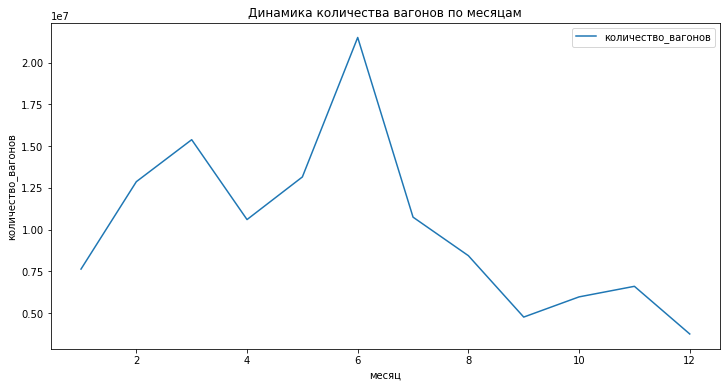

```python
(data.query('страна_отправления != "unknown" and страна_прибытия != "unknown"')
 .groupby('месяц')
 .agg({'количество_вагонов': 'sum'})
 .reset_index()
 .plot(x='месяц', y='количество_вагонов', figsize=(12, 6))
)
plt.xlabel('месяц')
plt.ylabel('количество_вагонов')
plt.title('Динамика количества вагонов по месяцам')
plt.show()
```

Отдельные графики каждого месяца с динамикой вагонов по направлениям:

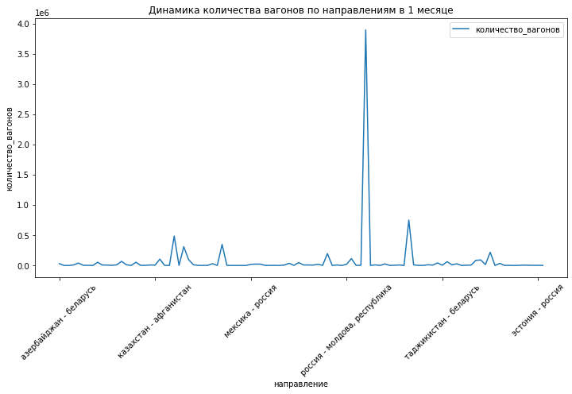

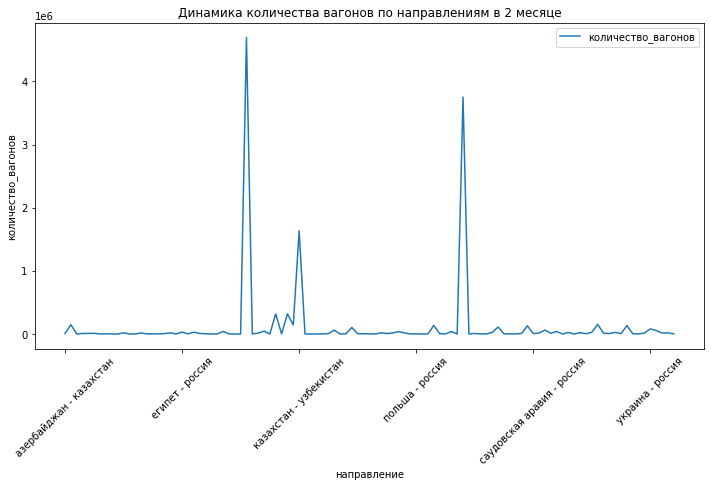

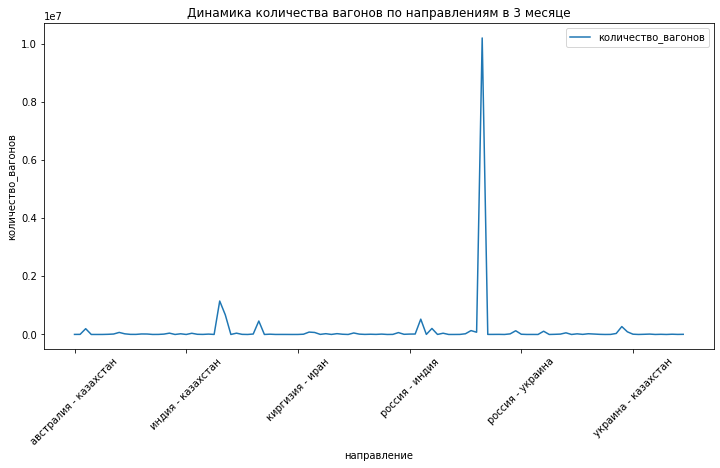

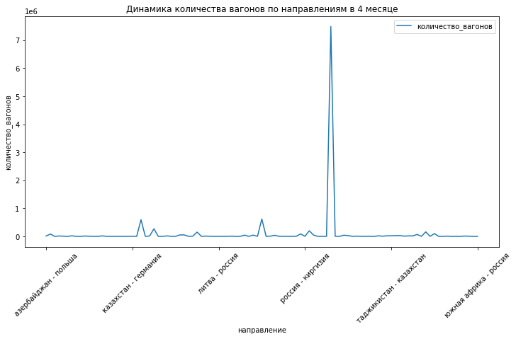

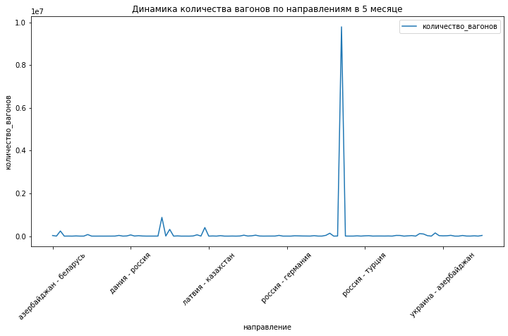

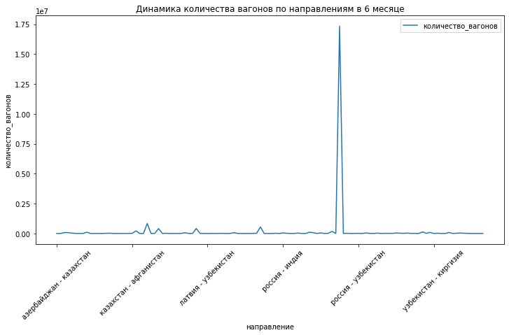

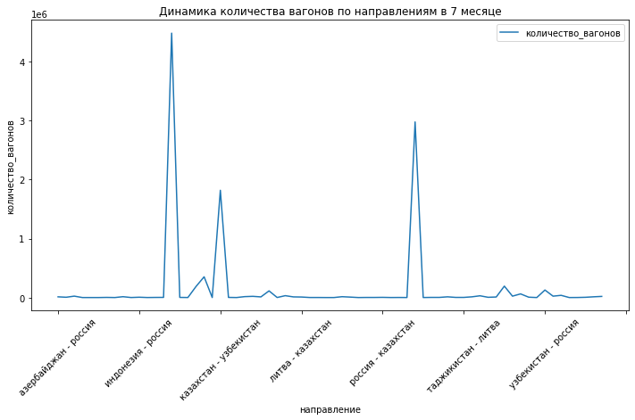

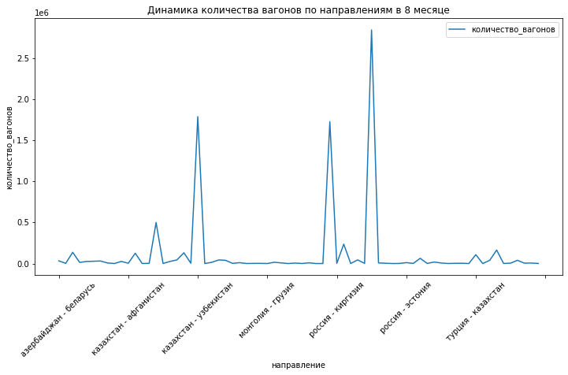

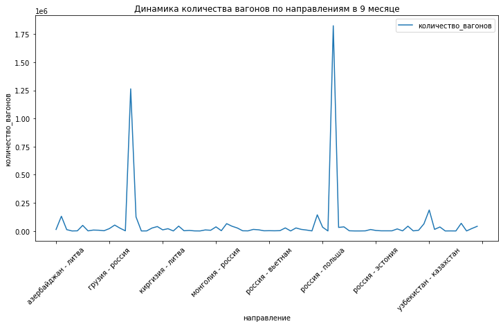

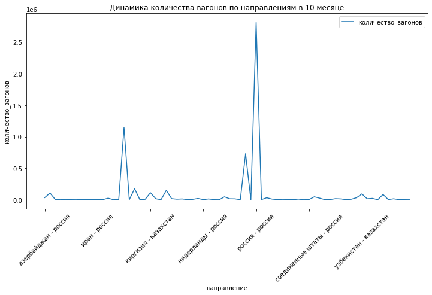

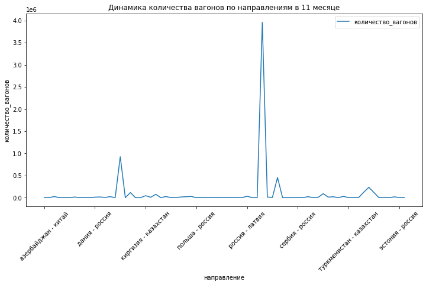

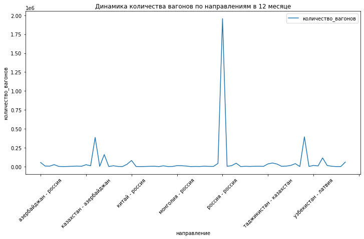

```python
for month in range(1, 13):
    (data.query('страна_отправления != "unknown" and страна_прибытия != "unknown" and месяц == @month')
     .groupby('направление')
     .agg({'количество_вагонов': 'sum'})
     .reset_index()
     .plot(x='направление', y='количество_вагонов', figsize=(12, 6))
    )
    plt.xlabel('направление')
    plt.xticks(rotation=45)
    plt.ylabel('количество_вагонов')
    plt.title(f'Динамика количества вагонов по направлениям в {month} месяце')
    plt.show()
```

Откинем выбросы с меньшей стороны и установим ограничение для с бОльшей стороны для наглядности:

```python
data['количество_вагонов'].describe()
```

```
count    9.678000e+03
mean     1.264635e+04
std      8.126644e+04
min      8.700000e+01
25%      2.000000e+02
50%      7.200000e+02
75%      3.420000e+03
max      1.882100e+06
Name: количество_вагонов, dtype: float64
```

```python
data['количество_вагонов'].describe()[5]
```

```
720.0
```

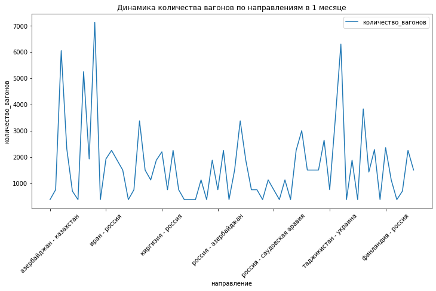

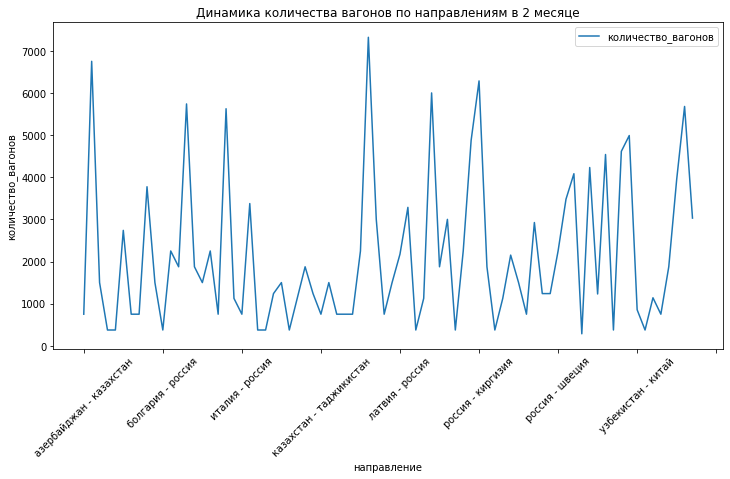

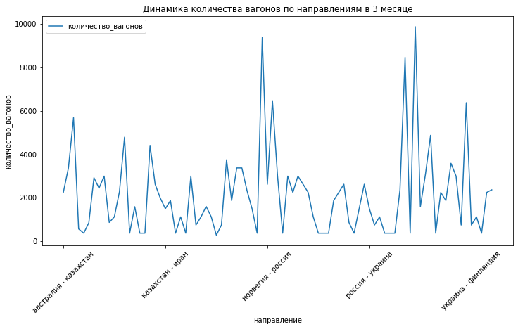

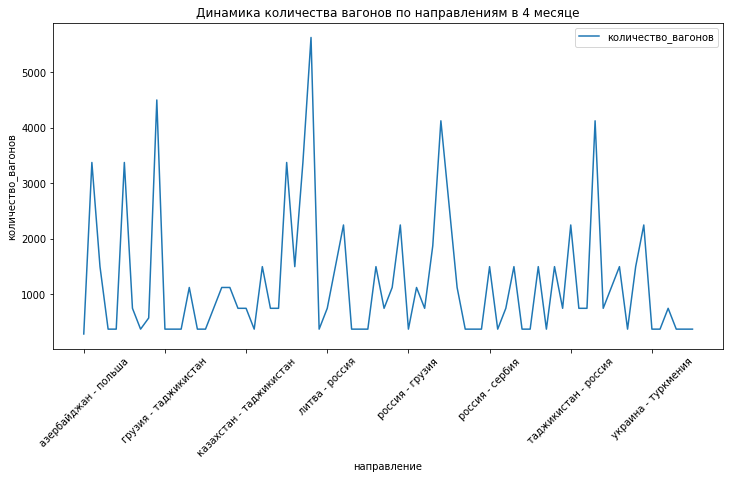

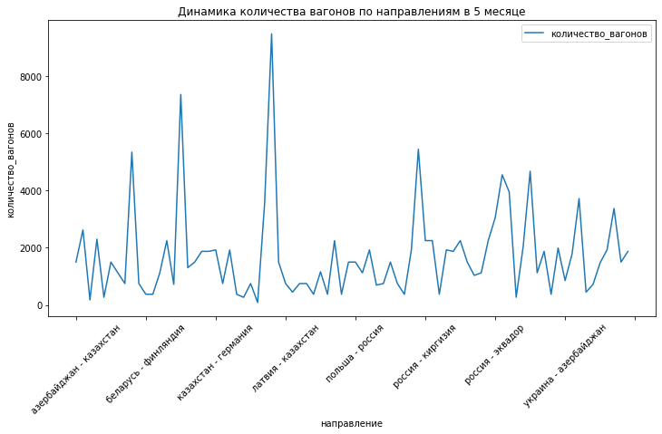

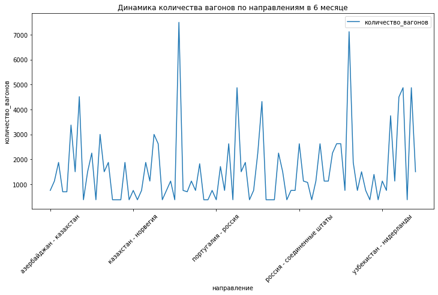

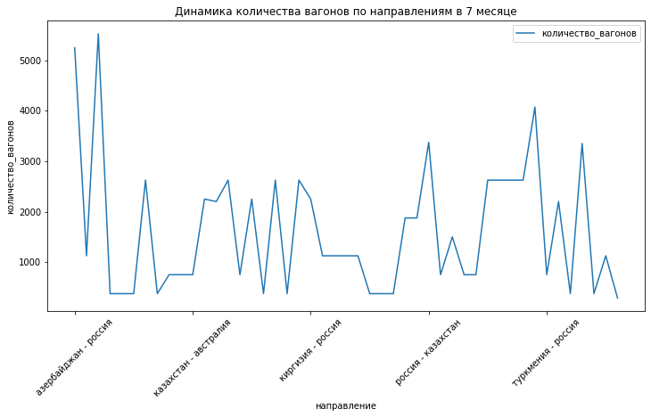

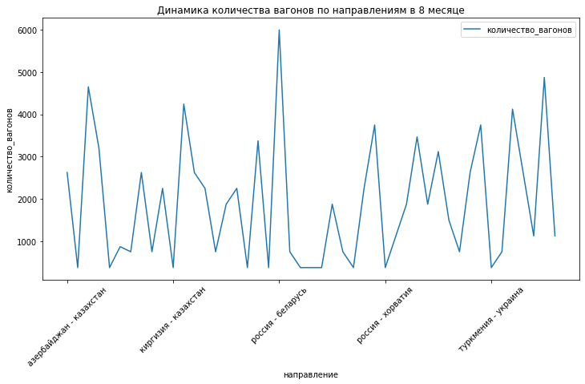

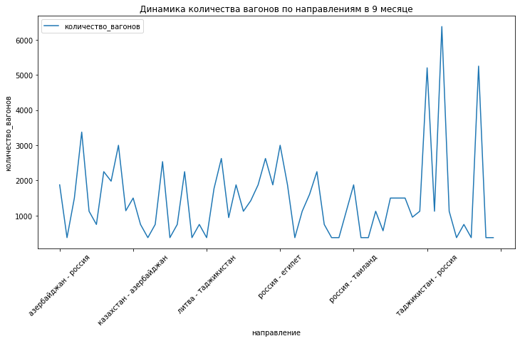

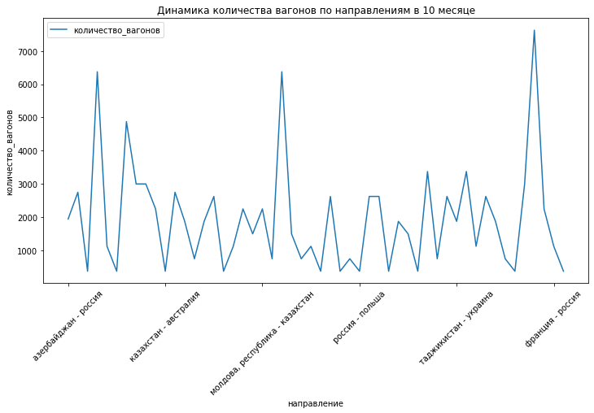

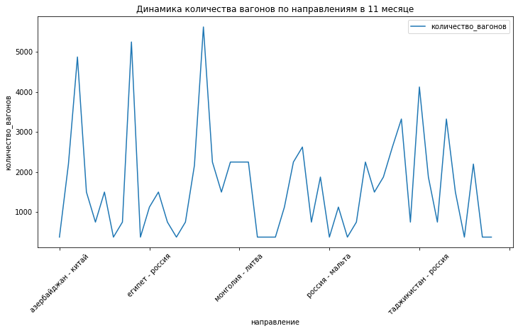

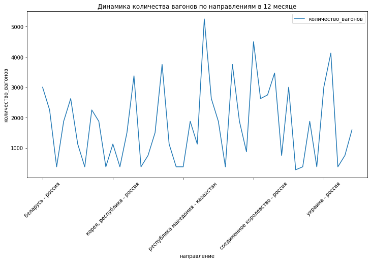

```python
for month in range(1, 13):
    tmp = data.query('страна_отправления != "unknown" and страна_прибытия != "unknown" and месяц == @month')
    #maximum = tmp['количество_вагонов'].mean() + (0.01 * np.std(tmp['количество_вагонов']))
    maximum = tmp['количество_вагонов'].describe()[5]
    minimum = tmp['количество_вагонов'].mean() - (3 * np.std(tmp['количество_вагонов']))
    three_sigma = tmp.query('@minimum < количество_вагонов < @maximum')
    (three_sigma
     .groupby('направление')
     .agg({'количество_вагонов': 'sum'})
     .reset_index()
     .plot(x='направление', y='количество_вагонов', figsize=(12, 6))
    )
    plt.xlabel('направление')
    plt.xticks(rotation=45)
    plt.ylabel('количество_вагонов')
    plt.title(f'Динамика количества вагонов по направлениям в {month} месяце')
    plt.show()
```